# Derivation of a prognostic signature for renal carcinoma

#### F) TUMOR STRATIFICATION NEEDED?

PCA plot voom obj function

Although there are clearly two populations (NAT and tumor, tumor is not clearly amenable to stratification – ie there is one, albeit phenotypically diverse tumor population)

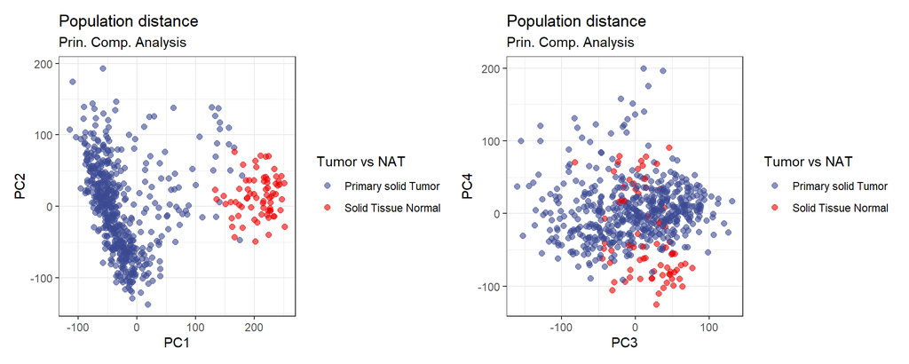

```r
plot_PCA_gg = function(vObj, condition_variable, pcs = c(1,2)){
  group = factor(vObj$targets[, condition_variable])
  pca = prcomp(t(vObj$E))

  pca_plot <- ggplot(pca$x, aes(pca$x[,pcs[1]], pca$x[,pcs[2]])) +
         geom_point(aes(color = group), alpha = 0.6, size = 2) +
    labs(x = paste0("PC", pcs[1]),
         y = paste0("PC", pcs[2]),
         subtitle = "Prin. Comp. Analysis", title = "Population distance") +
    scale_color_aaas()
  pca_plot
}

p.12 <- plot_PCA_gg(limma_res$voomObj, "definition", pcs = c(1,2))
p.34 <- plot_PCA_gg(limma_res$voomObj, "definition", pcs = c(3,4))

p.12 + p.34 & labs(color = "Tumor vs NAT")
```

Function to create scree plot

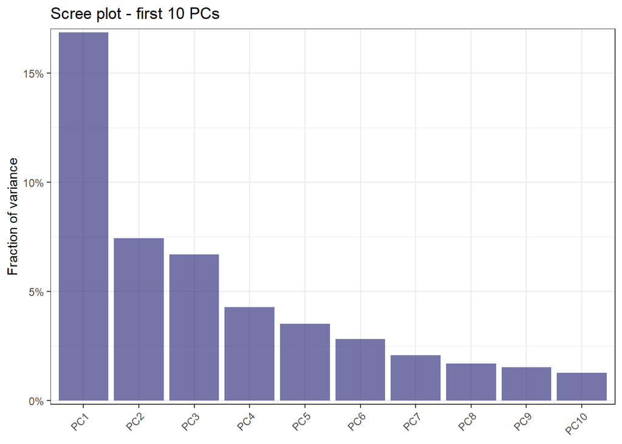

```r
plot_scree <- function(scaled_matrix) {

  pca <- prcomp(t(scaled_matrix))
  pca_stats <- stats:::summary.prcomp(pca)$importance[2, ]

  pca_stats %>%
    as.matrix %>%
    t() %>%
    as_tibble() %>%
    pivot_longer(everything()) %>%
    .[1:10,] %>%    # only the first 10 prin. comps
    ggplot(., aes(x = fct_reorder(name, -value), y = value, label = value)) +
    geom_bar(alpha = 0.6, stat = "identity", fun = "mean", fill = "midnightblue") +
    scale_y_percent() +
    labs(x = NULL, y = "Fraction of variance", title = "Scree plot - first 10 PCs") +
    theme(axis.text.x = element_text(angle = 45, hjust = 1))
}

plot_scree(limma_res$voomObj$E)
```

Use a Spearman correlation heat map of the VOOM-normalized series matrix to look at the prevalence of outliers and the number of tumor sample populations. If multiple, clearly-distinct tumor populations are present, sample stratification may be needed (i.e. comparing NAT to each stratified tumor population).

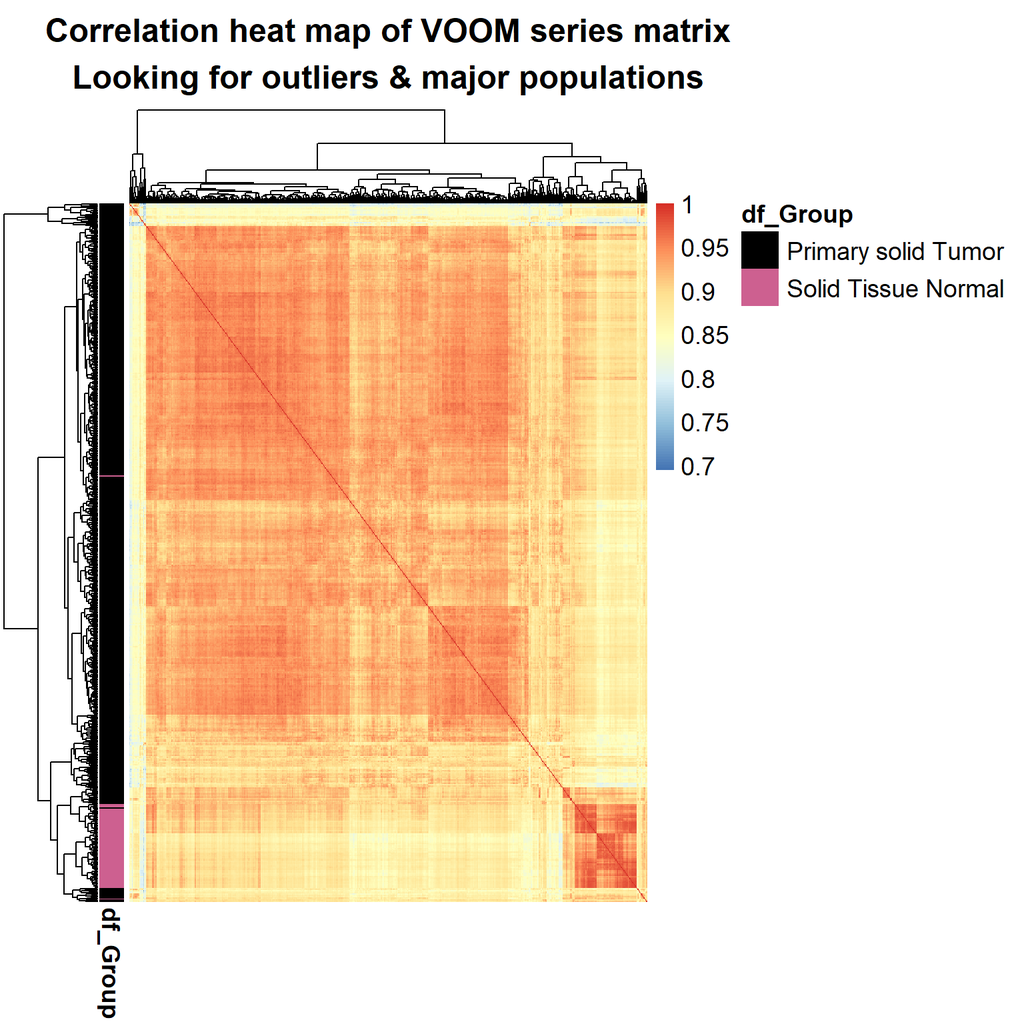

```r
VO <- voomObj[[3]]

annotation_row = data.frame(df_Group = factor(voomObj[[2]]$definition, ordered = TRUE))   # make row annotation
rownames(annotation_row) = voomObj[[2]]$barcode

cormat <- cor(VO, method = c("spearman"))   # correlation of all samples against each other
set.seed(123)
pheatmap(cormat,
         show_rownames = FALSE,
         show_colnames = FALSE,
         annotation_row = annotation_row,
         annotation_colors = list( df_Group = c("Primary solid Tumor"="black", "Solid Tissue Normal"="hotpink3")),
         fontsize=14,
         main = "Correlation heat map of VOOM series matrix\nLooking for outliers & major populations"
         )
```

```r
levels(annotation_row$df_Group)
```

```
## [1] "Primary solid Tumor" "Solid Tissue Normal"
```

Visualize frequency distribution of significant genes in top DEG (tumor vs NAT)

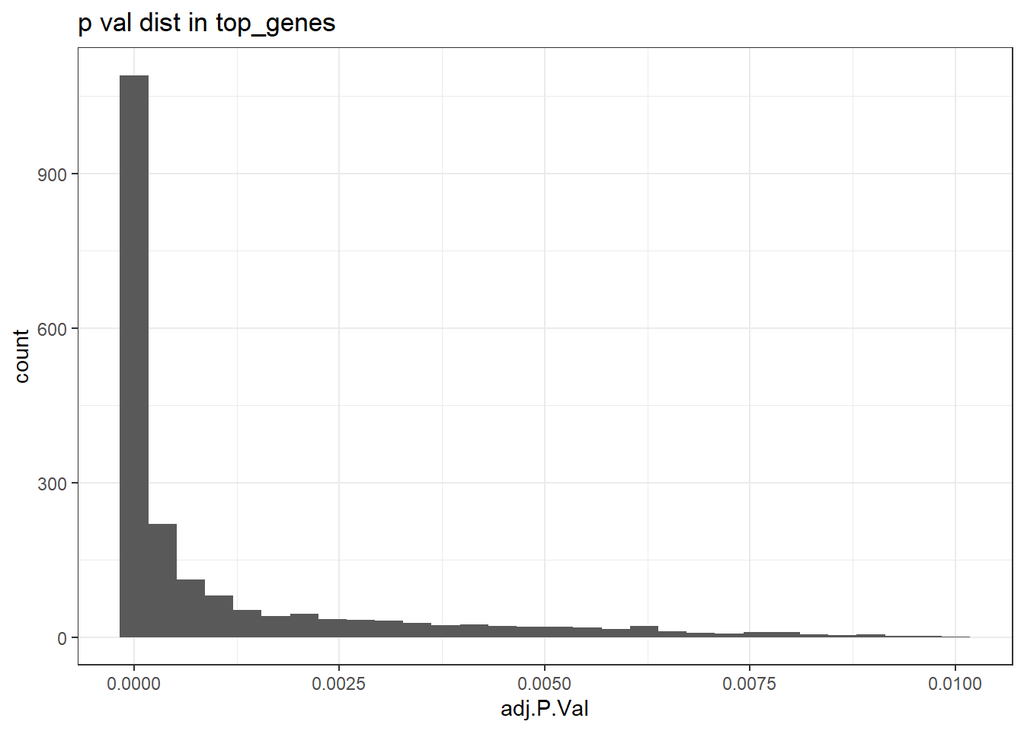

```r
expr_df = limma_res$topGenes

expr_df %>% ggplot(., aes(x = adj.P.Val)) +
  geom_histogram() +
  labs(title = "p val dist in top_genes")
```

Visualize top DEG (tumor vs NAT)

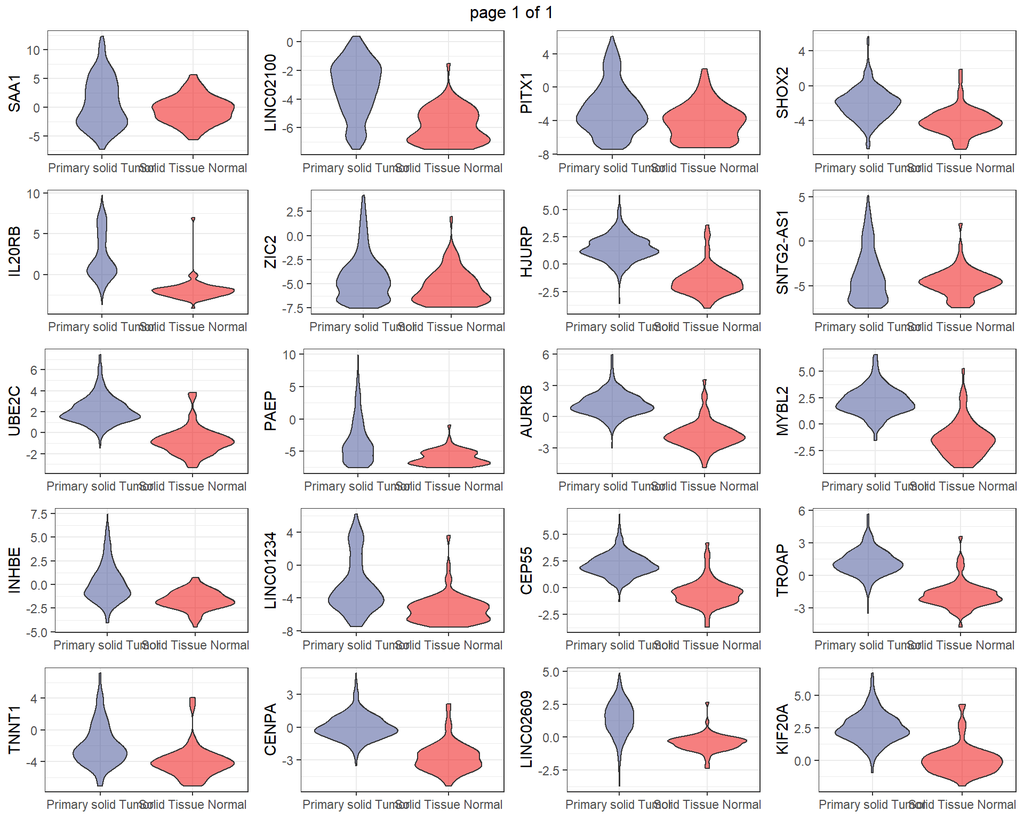

```r
meta_data <- limma_res$voomObj$targets

top_20_DEG <- top_treat %>%
  arrange(`adj.P.Val`) %>%
  head(., 20) %>%
  dplyr::select(ensembl_gene_id) %>% deframe

gene_vln <- function(gene) {
  gene_of_interest <- gene
  ext_gene_name <- limma_res$voomObj[[1]][gene_of_interest, "external_gene_name"]

  gene_meta <- t(limma_res$voomObj$E) %>%
    as_tibble(rownames = "barcode") %>%
    .[, c("barcode", gene_of_interest)] %>%
    left_join(., meta_data, by = "barcode")

  gene_meta %>% ggplot(., aes(definition, .data[[gene_of_interest]])) +
  geom_violin(aes(fill = definition), alpha = 0.5, show.legend = FALSE) +
  labs(y = ext_gene_name, x = NULL) +
  scale_fill_aaas()
}

map(top_20_DEG, ~ gene_vln(.x)) %>% marrangeGrob(., ncol = 4, nrow = 5)
```

#### G) SURVIVAL MODEL

```r
clin_df <- meta_data %>%
  as_tibble() %>%
  dplyr::filter(definition == "Primary solid Tumor") %>%
  dplyr::select("barcode", "patient", "vital_status", "days_to_death", "days_to_last_follow_up", "gender", "ajcc_pathologic_stage") %>%
  mutate(deceased = ifelse(vital_status == "Dead", TRUE, FALSE))

clin_df$overall_survival = ifelse(clin_df$deceased,
                                  clin_df$days_to_death,
                                  clin_df$days_to_last_follow_up)

d_mat <- varFilter(limma_res$voomObj$E, var.func=IQR, var.cutoff=0.95) %>% t()  # gives list of genes with high dispersion (top 5%)

# divide patients in two groups, up and down regulated.
# if the patient expression is greater or equal to them median we put it

pred_surv_pval <- function(x) {
  gene_id <- x
  median_value <- median(d_mat[,gene_id])

  d_meta_gene <- d_mat[,gene_id] %>%
    as_tibble(rownames = "barcode") %>%
    rename(., c("value" = "gene_value")) %>%
    inner_join(., clin_df, by = "barcode") %>%
    mutate(gene = ifelse(gene_value <= median_value, "DOWN", "UP"))

  # fit a survival model
  fit <- survfit(Surv(overall_survival, deceased) ~ gene, data=d_meta_gene)

  # extract the survival p-value
  pval = surv_pvalue(fit, data=d_meta_gene, method = "S1")$pval
  pval
}

surv_pvals <- map_dfr(colnames(d_mat),
                      ~ tibble(pval = pred_surv_pval(.x),
                               ENSG = paste(.x))) %>%
  mutate(FDR = p.adjust(pval, method = "BH")) %>%
  mutate(signif = ifelse(FDR <= 0.1, "signif", "non-signif"))

signif_pred_genes <- surv_pvals %>%
  dplyr::filter(signif == "signif") %>%  # FDR 10%
  dplyr::select(ENSG) %>%
  deframe
```

Refine the gene list above. Above, a gene list was identified that significantly predicted (in terms of pval) survival. However, pvalues have limited utility as sample numbers increase, so this list is refined below include samples with high fold changes (cutoff was 2^0.3219281 = 1.25 fold change; ie 25% change).

```r
fold_change <- function(x) {
d_meta_gene <- d_mat[, x] %>%
    as_tibble(rownames = "barcode") %>%
    inner_join(., clin_df, by = "barcode") %>%
    mutate(gene = ifelse(value <= median(value), "DOWN", "UP")) # stratify samples based on gene expression (above or below that gene's median expression)

two_average <- function(x) { log( x[1]/x[2], 2) }
two_average(c(2,4))

F2C <- d_meta_gene %>%
  group_by(gene) %>%
  summarize(average = mean(overall_survival)) %>%
  dplyr::select(average) %>%
  deframe() %>%
  two_average()
F2C
}

fold_change(signif_pred_genes[1])
```

```
## [1] 0.008822666
```

```r
df_fc <- map_dfr(signif_pred_genes, ~ tibble(FC_log2 = fold_change(.x),
                                    ENSG = paste(.x)))

genes_signif_hiFC <- df_fc %>% dplyr::filter(FC_log2 > 0.3219281) %>% dplyr::select(ENSG) %>% deframe
```

Plot the resulting gene list to look at each transcript’s prognostic value toward survival

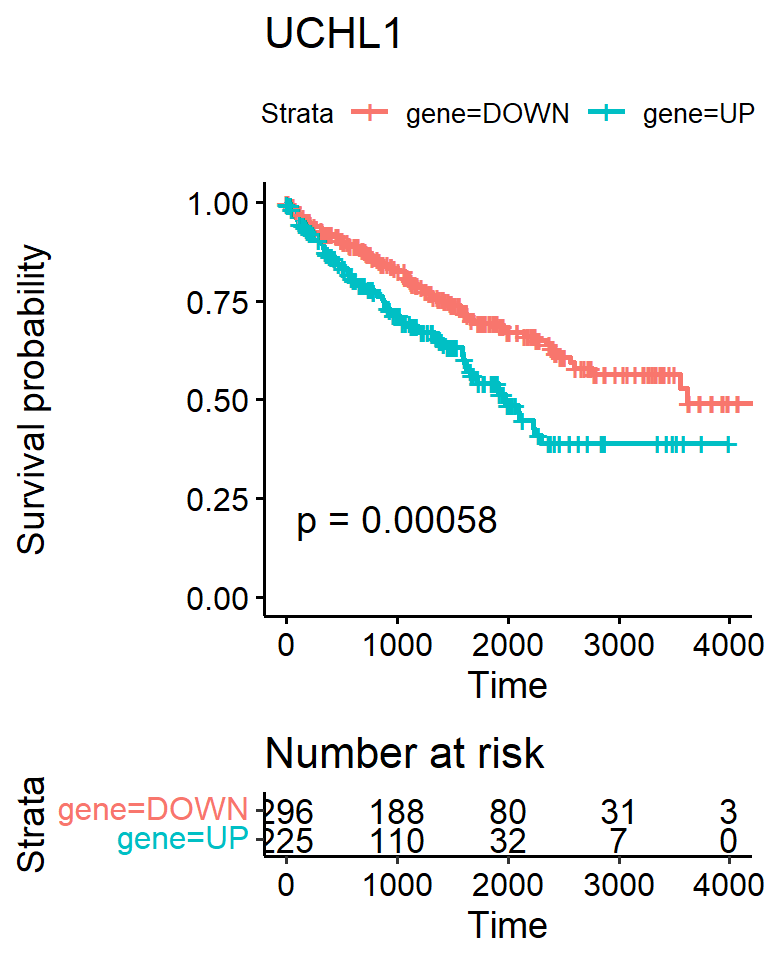

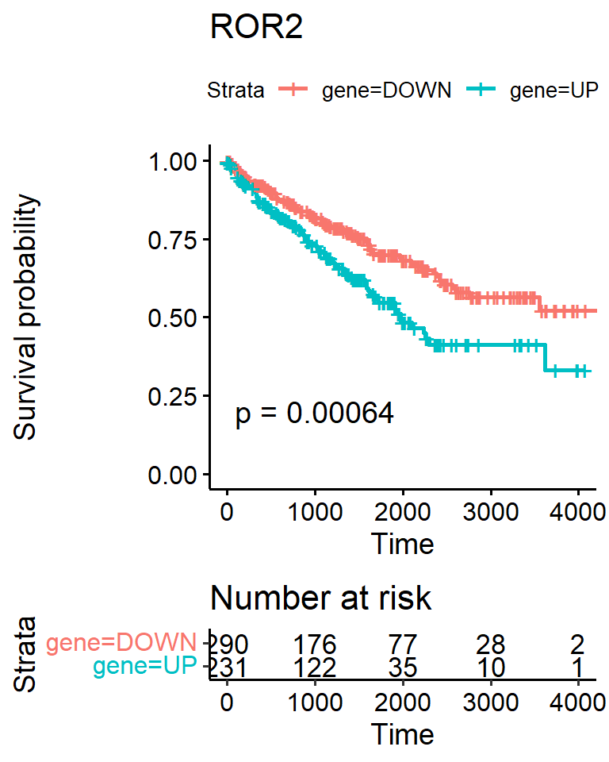

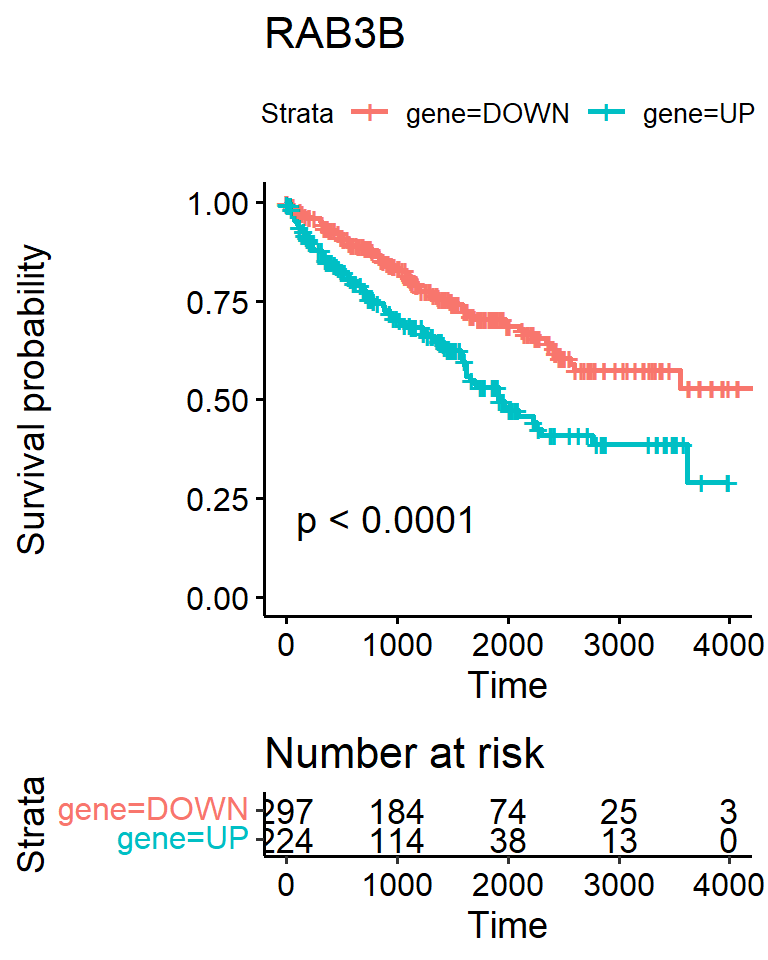

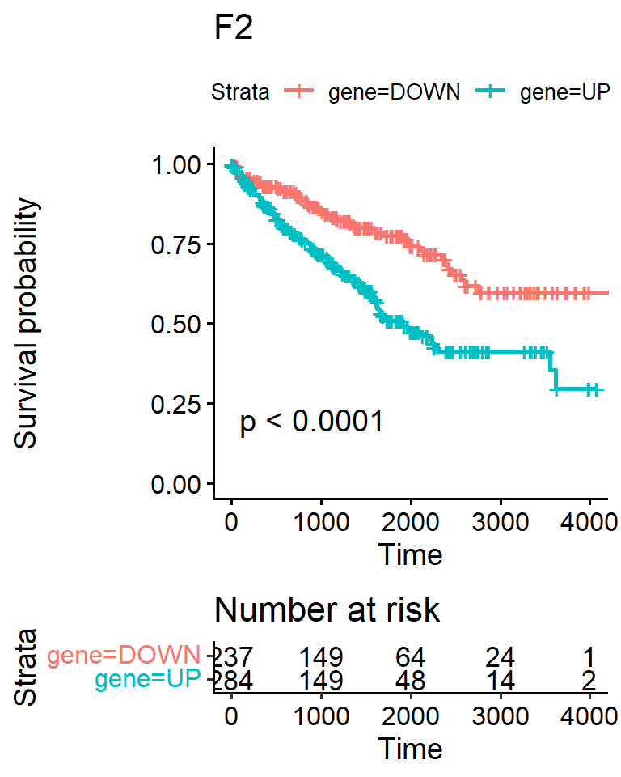

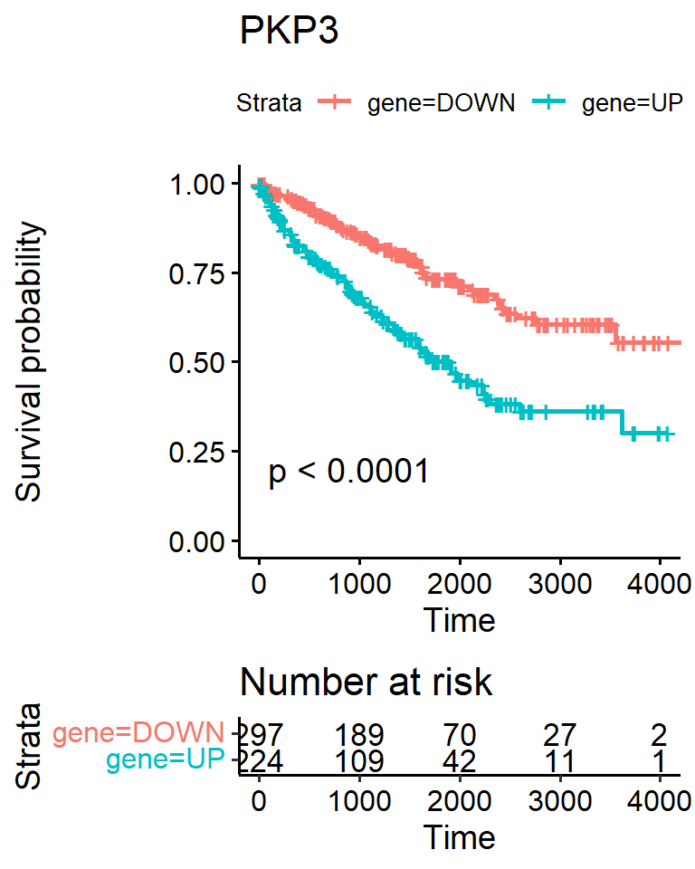

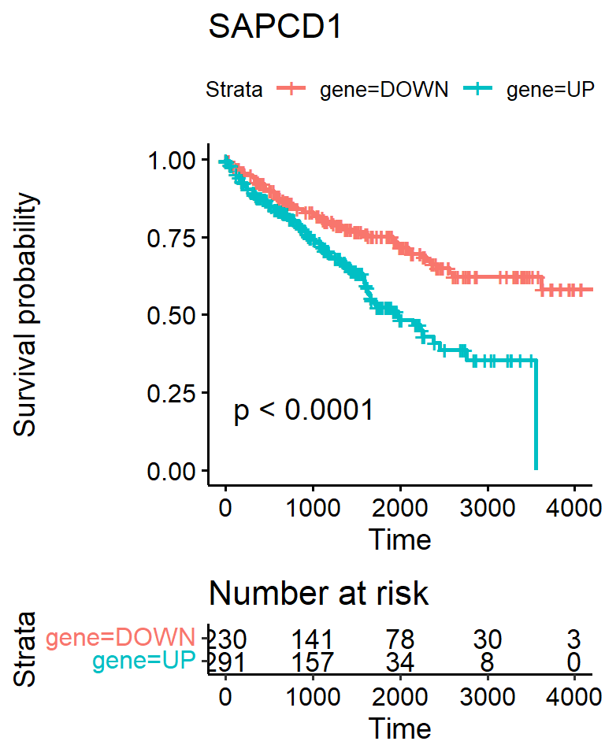

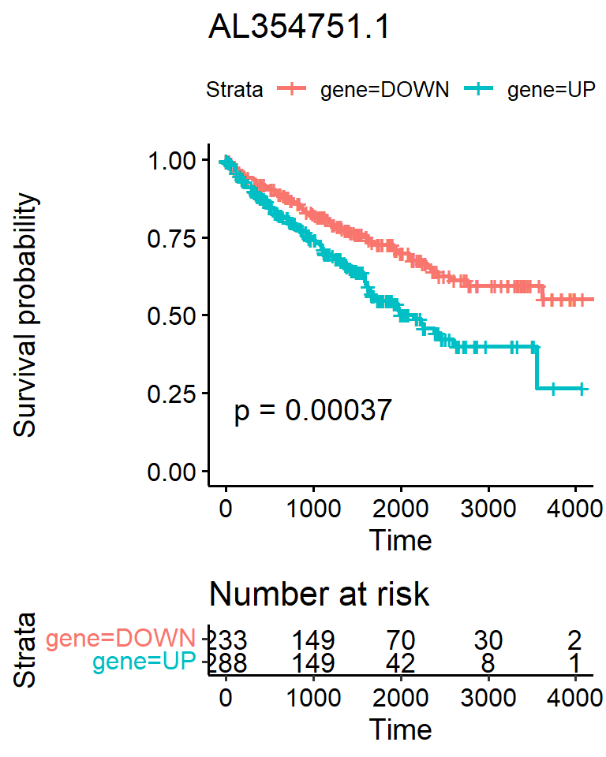

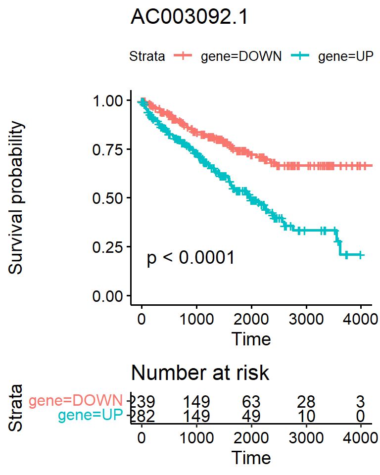

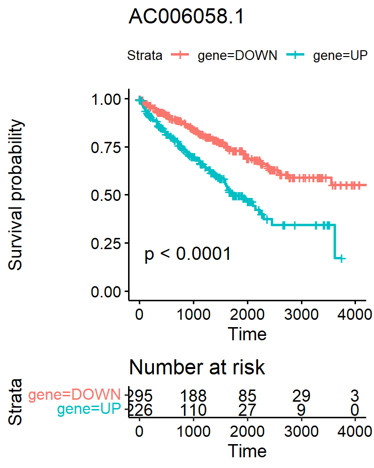

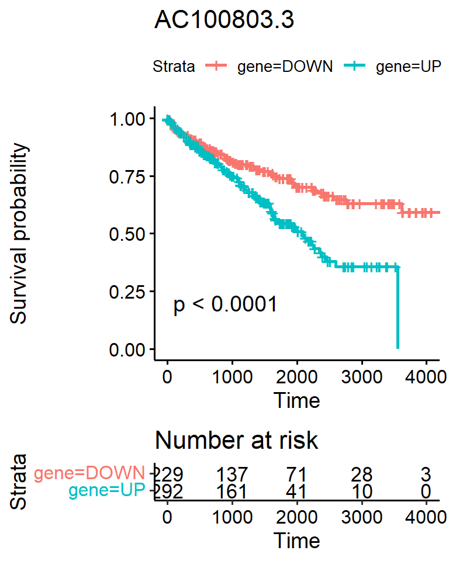

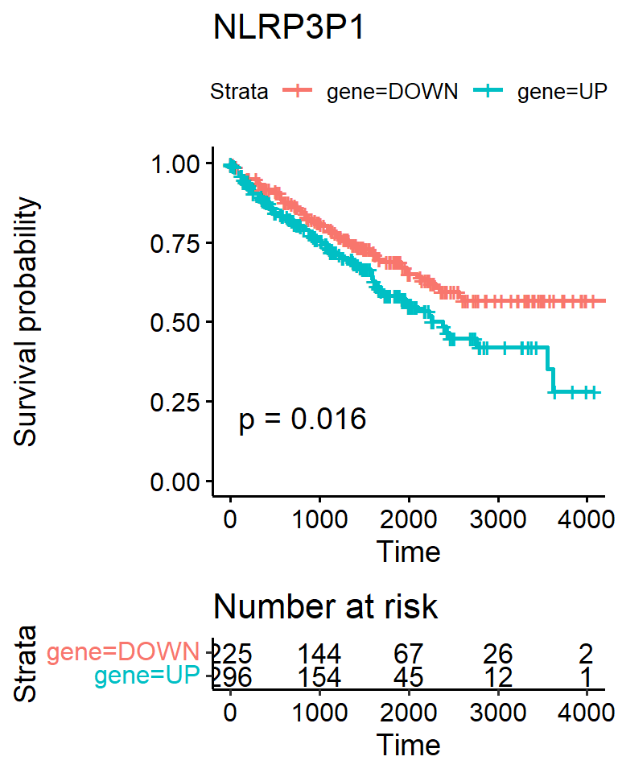

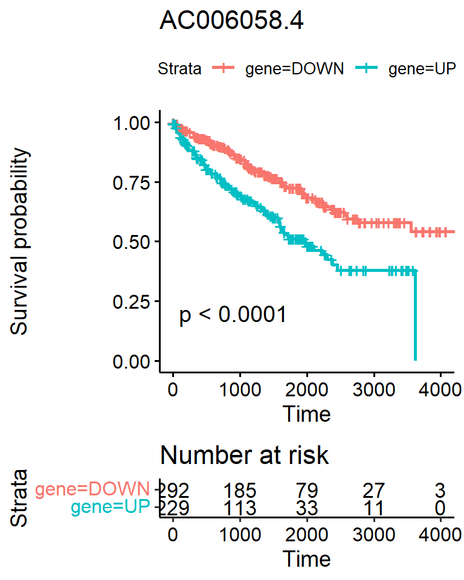

```r
plot_surv_wpval <- function(x) {
  gene_id <- x
  median_value <- median(d_mat[,gene_id])

  gene_name <- dge[[3]] %>%
    dplyr::filter(ensembl_gene_id == x) %>%
    dplyr::select(external_gene_name) %>% deframe

  d_meta_gene <- d_mat[,gene_id] %>%
    as_tibble(rownames = "barcode") %>%
    rename(., c("value" = "gene_value")) %>%
    inner_join(., clin_df, by = "barcode") %>%
    mutate(gene = ifelse(gene_value <= median_value, "DOWN", "UP"))

  fit <- survfit(Surv(overall_survival, deceased) ~ gene, data=d_meta_gene)

  ggsurvplot(fit, data=d_meta_gene, pval=T, risk.table=T, title=paste(gene_name))

}

map(genes_signif_hiFC, ~ plot_surv_wpval(.x))
```

Signature of genes that predict survival

```r
final_signature <- dge[[3]] %>% dplyr::filter(ensembl_gene_id %in% genes_signif_hiFC)
final_signature
```

|  | ensembl_gene_id | external_gene_name | original_ensembl_gene_id |
| --- | --- | --- | --- |
| ENSG00000154277 | ENSG00000154277 | UCHL1 | ENSG00000154277.11 |
| ENSG00000169071 | ENSG00000169071 | ROR2 | ENSG00000169071.13 |
| ENSG00000169213 | ENSG00000169213 | RAB3B | ENSG00000169213.6 |
| ENSG00000180210 | ENSG00000180210 | F2 | ENSG00000180210.13 |
| ENSG00000184363 | ENSG00000184363 | PKP3 | ENSG00000184363.8 |
| ENSG00000228727 | ENSG00000228727 | SAPCD1 | ENSG00000228727.7 |
| ENSG00000234537 | ENSG00000234537 | AL354751.1 | ENSG00000234537.1 |
| ENSG00000236453 | ENSG00000236453 | AC003092.1 | ENSG00000236453.4 |
| ENSG00000261786 | ENSG00000261786 | AC006058.1 | ENSG00000261786.1 |
| ENSG00000271959 | ENSG00000271959 | AC100803.3 | ENSG00000271959.1 |

[output cut: 2 more lines]

These genes have known relationships to tumor staging and pathogenesis, including the Wnt signalling (ROR2) and TGFbeta (AC100803.3) signalling pathways. The signature can be used to estimate patient outcome in renal cell carcinoma.